# DATA-413/613 Homework: Tidy Text

6. Measure the total for each nrc sentiment in each block of **500** lines and then,
- Filter out the “positive” and “negative” and save to a new variable. You should have 464 observations.
- Plot the count of the sentiments for each block in each book in an appropriate faceted plot with the books in two columns and the sentiments in 8 rows.
- Be sure to remove the legend.
- Interpret the plots for each book and then compare them.
- Why did the values drop off so suddenly at the end?

```r
drops <- c("positive", "negative")
get_sentiments("nrc") %>%
  filter(!sentiment %in% drops) %>% #filter out
  inner_join(combined, by = "word") %>% #join in combined
  count(index = line_num %/% 500, sentiment, book, sort = TRUE) -> nrc_combined

nrow(nrc_combined) #correct number of rows
```

```
## [1] 464
```

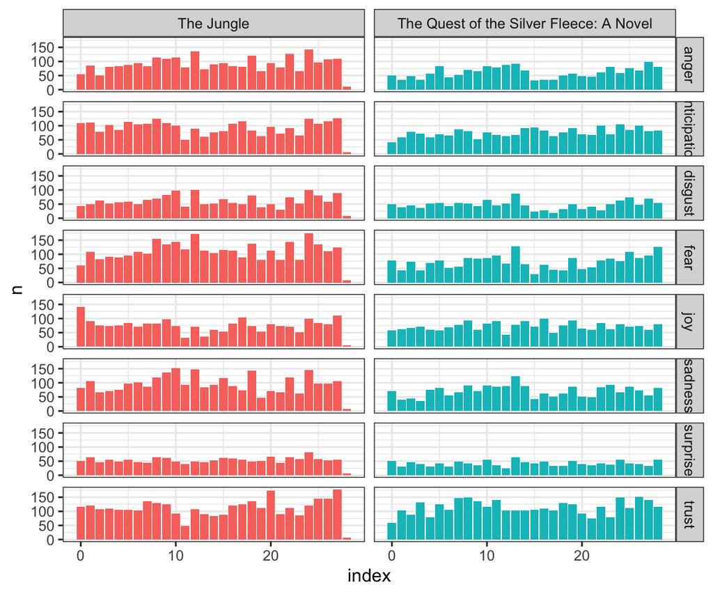

```r
nrc_combined %>%
ggplot(aes(x = index, y = n, fill = book)) +
geom_bar(stat = "identity", show.legend = F) +
facet_grid(sentiment~book) +
theme_bw()
```

Generall speaking, The Jungle had more counts of every sentiment. That being said The Jungle seemed to have comparatively large amounts of “fear”, “anger”, and “sadness”. Conversely, the Quest of the Silver Fleece seemed to have a lot of “trust” and “anticipation”. Both books had constant levels of “surprise. Based on these sentiments, one might anticipate that The Jungle is a more sensational book.

The values dropped off suddenly at the end because there weren’t enough indexes for a full 500 line block.

7. Using bing, create a new data frame with the counts of the positive and negative sentiment words for each book.
- Show the “top 20” most frequent words in a book (*looking across both books*) along with their book, sentiment, and count, in descending order by count.
- What are the positive words in the list of “top 20”?

```r
combined %>%
  inner_join(get_sentiments("bing"), by = "word") %>%
  count(book, word, sentiment, sort = TRUE) %>%
  arrange(desc(n)) %>%
  head(n=20) -> bing20

bing20 #top 20, in descending order by count
```

```
## # A tibble: 20 × 4
##    book                                    word    sentiment     n
##    <chr>                                   <chr>   <chr>     <int>
##  1 The Quest of the Silver Fleece: A Novel miss    negative    467
##  2 The Quest of the Silver Fleece: A Novel slowly  negative    124
##  3 The Quest of the Silver Fleece: A Novel dark    negative     96
##  4 The Jungle                              poor    negative     80
##  5 The Jungle                              cold    negative     79
##  6 The Jungle                              hard    negative     61
##  7 The Jungle                              lost    negative     61
##  8 The Jungle                              wild    negative     55
##  9 The Quest of the Silver Fleece: A Novel love    positive     54
## 10 The Jungle                              fell    negative     51
## 11 The Quest of the Silver Fleece: A Novel fell    negative     50
## 12 The Quest of the Silver Fleece: A Novel mighty  positive     48
## 13 The Jungle                              death   negative     47
## 14 The Jungle                              free    positive     44
## 15 The Jungle                              killing negative     43
## 16 The Quest of the Silver Fleece: A Novel silent  positive     43
## 17 The Jungle                              cry     negative     41
## 18 The Jungle                              agony   negative     40
## 19 The Quest of the Silver Fleece: A Novel hard    negative     40
## 20 The Jungle                              dead    negative     39
```

```r
#only the positives
bing20 %>%
  filter(sentiment == "positive")
```

```
## # A tibble: 4 × 4
##   book                                    word   sentiment     n
##   <chr>                                   <chr>  <chr>     <int>
## 1 The Quest of the Silver Fleece: A Novel love   positive     54
## 2 The Quest of the Silver Fleece: A Novel mighty positive     48
## 3 The Jungle                              free   positive     44
## 4 The Quest of the Silver Fleece: A Novel silent positive     43
```

8. Plot the top ten positive and top ten negative sentiments just for each book, faceting by book and sentiment (total 20 words per book).
- Ensure each facet has the words in the proper order for that book.
- Identify any that may be inappropriate for the context of the book and should be excluded from the sentiment analysis.

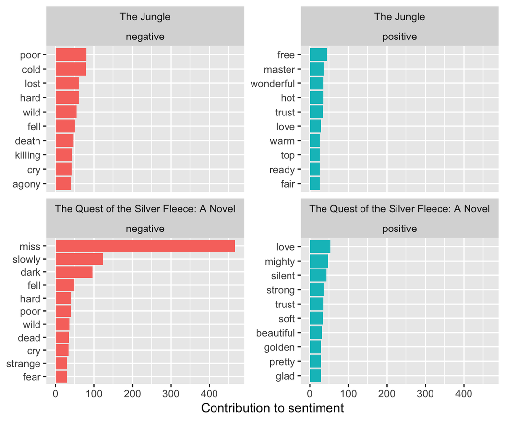

```r
combined %>%
  inner_join(get_sentiments("bing"), by = "word") %>%
  count(book, word, sentiment, sort = TRUE) %>%
  arrange(desc(n)) %>%
  group_by(book, sentiment) %>%
  slice_max(n, n = 10)%>%
  ungroup() %>%
  ggplot(aes(x = reorder_within(word, n, book), y = n, fill = sentiment)) +
  geom_col(show.legend = FALSE) +
  facet_wrap(book~sentiment, scales = "free_y") +
  coord_flip() +
  scale_x_reordered() +
  labs(y = "Contribution to sentiment", x = NULL)
```

The word “miss” seems inappropriate for the analysis given when these books were published.

9. Remove the inappropriate word(s) from the analysis.
- Replot the top 10 for each sentiment per book from step 8 (total 20 words per book).
- Interpret the plots

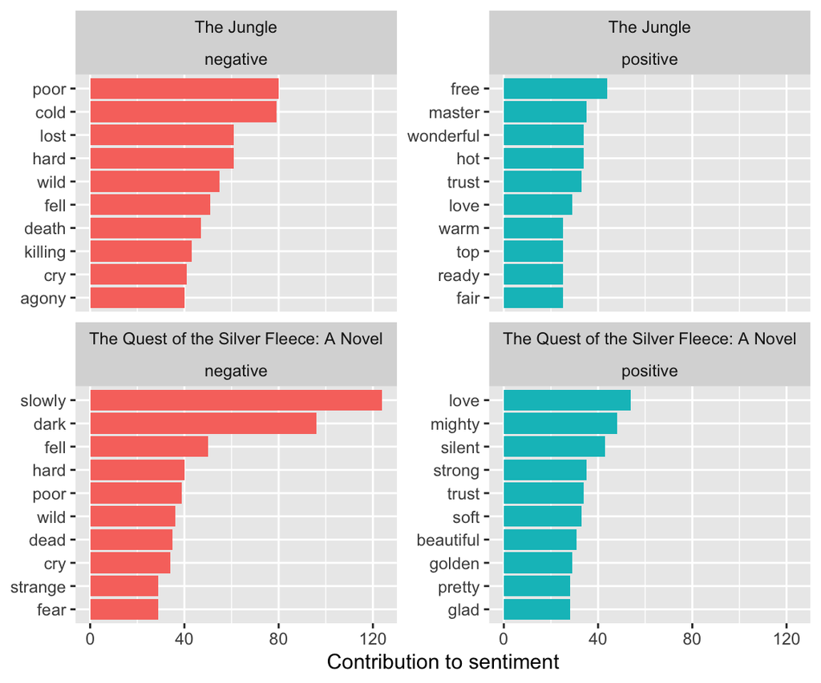

```r
#excluding "miss"
combined %>%
  inner_join(get_sentiments("bing"), by = "word") %>%
  count(book, word, sentiment, sort = TRUE) %>%
  filter(word != "miss") %>%
  arrange(desc(n)) %>%
  group_by(book, sentiment) %>%
  slice_max(n, n = 10) %>%
  ungroup() %>%

  ggplot(aes(x = reorder_within(word, n, book), y = n, fill = sentiment)) +
  geom_col(show.legend = FALSE) +
  facet_wrap(book ~ sentiment, scales = "free_y") +
  coord_flip() +
  scale_x_reordered() +
  labs(y = "Contribution to sentiment", x = NULL)
```

10. Rerun the analysis from step 5 and recreate the plot with the title “Custom Bing”.
- Show both the original step 5 plot with the new plot in the same output graphic, one on top of the other so the books are above each other (in columns) with original in the top row and custom in the second row.
- Interpret the plots

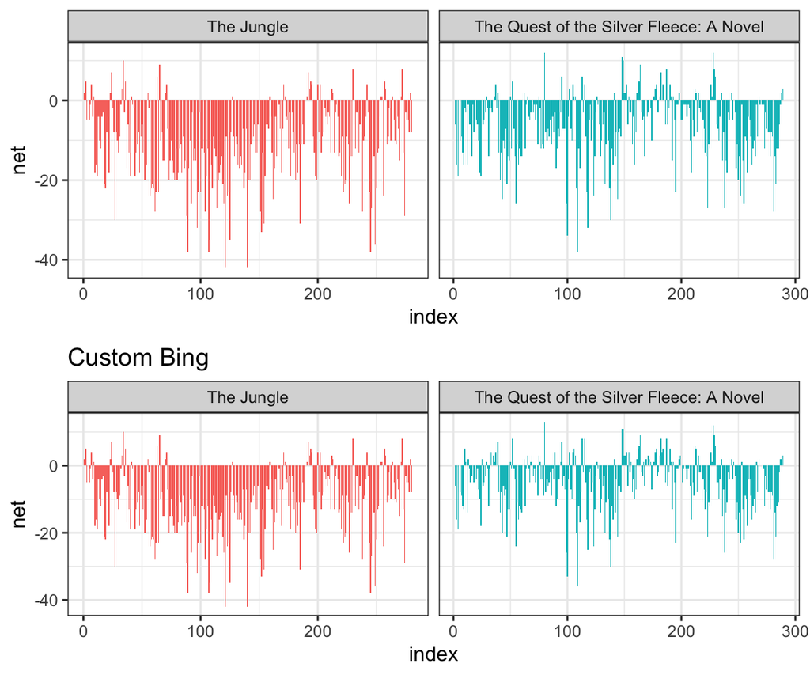

```r
combined %>%
  inner_join(get_sentiments("bing"), by = "word") %>%
  filter(word != "miss") %>%
  count(index = line_num %/% 50, sentiment, book, sort = TRUE) %>%
  pivot_wider(names_from = sentiment, values_from = n,
              values_fill = list(n = 0)) %>%
  mutate(net = positive - negative) %>%

  ggplot(aes(x = index, y = net, fill = book)) +
  geom_col(show.legend = FALSE) +
  facet_grid(~book,  scales = "free_x") +
  theme_bw() +
  ggtitle("Custom Bing") -> custombing

gridExtra::grid.arrange(combined_bing_50, custombing)
```

# 2 tf-idf for A Selection of Mark Twain’s books

1. Use a single call to download all the following *complete* books by author Mark Twain from Project Gutenberg
- Use the `meta_fields` argument to include the book title as part of the download
- *Huckleberry Finn*, *Tom Sawyer* , *Connecticut Yankee in King Arthur’s Court*, *Life on the Mississippi* , *Prince and the Pauper*, and *A Tramp Abroad*

```r
gutenberg_works() %>%
  filter(str_detect(author,"Twain, Mark")) %>%

# filtered using str_detect() on title a few times to identify the
# relevant IDs of interest

#76 Adventures of Huckleberry Finn
#74 The Adventures of Tom Sawyer, Complete
#86 A Connecticut Yankee in King Arthur's Court
#245    Life on the Mississippi
#1837   The Prince and the Pauper
#119    A Tramp Abroad

  filter(gutenberg_id %in% c(76, 74, 86, 245, 1837, 119)) %>%
  gutenberg_download(meta_fields = "title") -> Twain
```

2. Modify your earlier function to create a new one called `tidydoctf()` to output a tf-idf ready dataframe where now you **leave the the stop words in the text**.
- Unnest at the word level, remove any formatting, and get rid of any `NA`s.
- Add the count for each word by title.
- Use your function to tidy the downloaded texts and save to a variable. It should have 56,759 rows.

```r
tidydoctf <- function(df) {

df %>%

  unnest_tokens(word, text) %>%
  mutate(word = str_extract(word, "[a-z']+")) %>%
  filter(!is.na(word)) %>%
  count(title, word, sort = TRUE) -> df_words

df_words %>%
  group_by(title) %>%
  summarize(total = sum(n), .groups = "keep") -> total_words

df_words %>%
  left_join(total_words, by = "title") -> df_words

df_words

}
tidydoctf(Twain) -> Twain
```

3. Calculate the tf-idf
- Save back to the data frame.

```r
Twain %>%
  bind_tf_idf(word, title, n) -> Twain
head(Twain)
```

```
## # A tibble: 6 × 7
##   title                                   word      n  total     tf   idf tf_idf
##   <chr>                                   <chr> <int>  <int>  <dbl> <dbl>  <dbl>
## 1 A Tramp Abroad                          the    9915 159369 0.0622     0      0
## 2 Life on the Mississippi                 the    9175 147364 0.0623     0      0
## 3 Adventures of Huckleberry Finn          and    6374 113296 0.0563     0      0
## 4 A Tramp Abroad                          and    6241 159369 0.0392     0      0
## 5 A Connecticut Yankee in King Arthur's … the    6091 119089 0.0511     0      0
## 6 Life on the Mississippi                 and    5966 147364 0.0405     0      0
```

4. Plot the tf for each book using a faceted graph.
- Facet by book and *constrain the data or the X axis to see the shape of the distribution*.

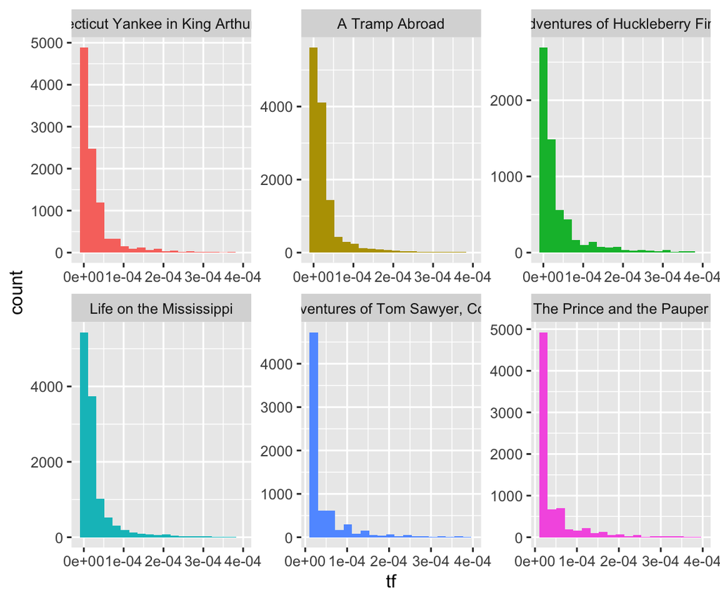

```r
#max(Twain$tf) Max tf is .062

Twain %>%
  group_by(title) %>%
  ggplot(aes(x = tf, fill = title)) +
  geom_histogram(bins = 20, show.legend = F) +
  facet_wrap(~title, scales = "free") +
  xlim(NA, 0.0004)
```

5. Show the words with the 15 highest tf-idfs across across all books
- Only show those rows.
- From just looking at the output, which ones look like possible names?

```r
Twain %>%
  slice_max(tf_idf, n = 15)
```

```
## # A tibble: 15 × 7
##    title                                word      n  total      tf   idf  tf_idf
##    <chr>                                <chr> <int>  <int>   <dbl> <dbl>   <dbl>
##  1 The Prince and the Pauper            hend…   161  71104 2.26e-3 1.79  0.00406
##  2 The Adventures of Tom Sawyer, Compl… becky   115  72189 1.59e-3 1.79  0.00285
##  3 The Adventures of Tom Sawyer, Compl… huck    258  72189 3.57e-3 0.693 0.00248
##  4 The Prince and the Pauper            canty    97  71104 1.36e-3 1.79  0.00244
##  5 The Prince and the Pauper            prin…   191  71104 2.69e-3 0.693 0.00186
##  6 Adventures of Huckleberry Finn       warn…   293 113296 2.59e-3 0.693 0.00179
##  7 The Adventures of Tom Sawyer, Compl… joe     170  72189 2.35e-3 0.693 0.00163
##  8 Adventures of Huckleberry Finn       en      235 113296 2.07e-3 0.693 0.00144
##  9 The Adventures of Tom Sawyer, Compl… don     224  72189 3.10e-3 0.405 0.00126
## 10 Adventures of Huckleberry Finn       didn…   347 113296 3.06e-3 0.405 0.00124
## 11 Adventures of Huckleberry Finn       don't   341 113296 3.01e-3 0.405 0.00122
## 12 The Adventures of Tom Sawyer, Compl… sid      80  72189 1.11e-3 1.10  0.00122
## 13 The Adventures of Tom Sawyer, Compl… ain     123  72189 1.70e-3 0.693 0.00118
## 14 Life on the Mississippi              pilo…    93 147364 6.31e-4 1.79  0.00113
## 15 Adventures of Huckleberry Finn       ain't   299 113296 2.64e-3 0.405 0.00107
```

Some possible names include: joe, hendon, becky, don

6. Plot the top 7 tf_idf words from each book again faceted by book.
- Sort in descending order of tf_idf
- Interpret the plots.

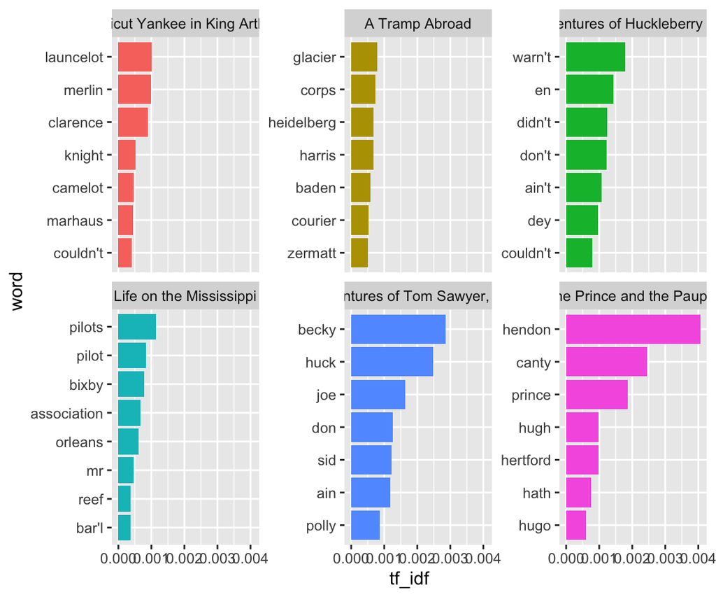

```r
Twain %>%
  group_by(title) %>%
  slice_max(tf_idf, n = 7) %>%
  mutate(word = fct_reorder(word, tf_idf)) %>%

  ggplot(aes(x = word, y = tf_idf, fill = title)) +
  geom_col(show.legend = FALSE) +
  facet_wrap(~title, scales = "free_y") +
  coord_flip()
```

Of the Top 7 tf_idfs most are names (polly, becky, merlin, etc.). There are also multiple titles like “mr”. Finally, many of the words are stop words like “didn’t”, “don’t”, and “ain’t”.

# 3 Extra Credit Podcasts

- Choose **One** of the following podcasts and answer the questions below:
1. [Sentiment Preserving Fake Reviews](https://podcasts.apple.com/us/podcast/data-skeptic/id890348705?i=1000483067378)  
   The [Original paper](https://arxiv.org/abs/1907.09177)
2. [Data in Life: Authorship Attribution in Lennon-McCartney Songs](https://podcasts.apple.com/us/podcast/authorship-attribution-of-lennon-mccartney-songs/id890348705?i=1000485519404)
1. What are some key ideas from this podcast relevant to text sentiment analysis/authorship attribution?
2. How do you think the ideas discussed may be relevant in your future work?

In the future, I hope to work to counter disinformation/misinformation. At the beginning of the first podcast, the speakers talked about how with deepfakes something seems “off” – i.e., they are visually not quite right. However, for text we might not have an easy way to distinguish this same thing. As the hosts discuss, NLP might become a powerful tool in this domain. Still, more work needs to be done in refining and training various models but NLP might allow for the creation of ‘risk scores’ evaluating whether a human authored a post sometime in the future.